```python
from IPython.display import HTML

HTML('''<script>
code_show=true;
function code_toggle() {
 if (code_show){
 $('div.input').hide();
 } else {
 $('div.input').show();
 }
 code_show = !code_show
}
$( document ).ready(code_toggle);
</script> <a href="javascript:code_toggle()"></a>''')
```

# Brand Monitoring Tool

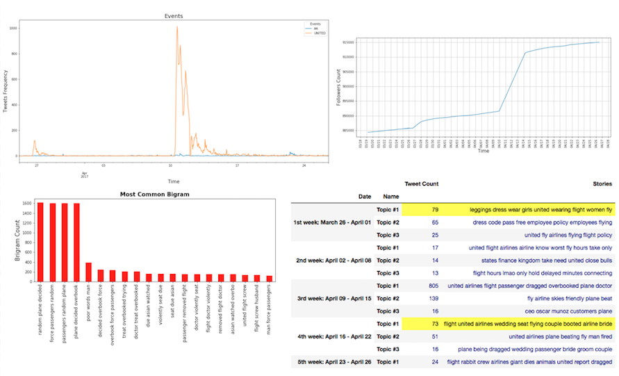

```python
from IPython.display import HTML, display
Image(filename='TDI/tool2.png')
```

# Public Relation Crisis Management Analysis

[figure not shown]

```python
Image(filename='TDI/United-Airlines-passenger-dragged-overbooked-flight-790214.jpg', width=800, height=600)
```

## Analysis of Tweets Frequency and Events:

### Plot #1: Events Plot for American Airlines and United Airlines

```python
#display(HTML("<tr><td><img src='TDI/timeseries_brands_ua.html'></td></tr>"))
```

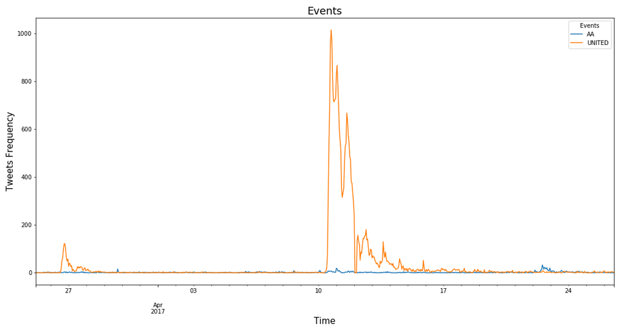

```python
from IPython.display import Image
Image(filename='TDI/timeseries_events_3.png')
```

### Plot #2: Zoomed Events Graph for United Airlines

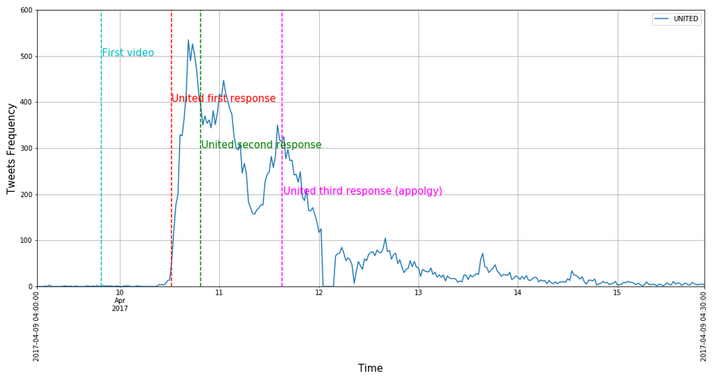

```python
Image(filename='TDI/timeseries_ua_zoom_3.png')
```

## Change in Number of UA Followers Over Time

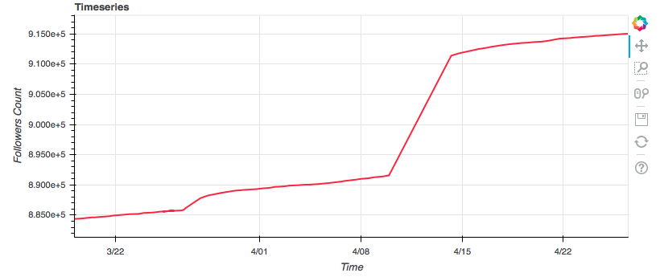

```python
# Image(filename='TDI/ua_follower_march_april2.png')
Image(filename='TDI/followers.png')
```

## Discovering Stories by Topic Modeling

I give an overview of stories covered in the twitter collection using topic modeling and clustering tweets together as stories. Steps to create clusters of tweets that are less noisy and more informative, including:

- divided my twitter collection into time slices of one week.
- Noise and common word removal
- Tweet tokenizing using NLTK
- TFIDF
- Topic modeling(Latent Semantic Analysis)
- added a probability threshold to further remove the noise tweets in each cluster.

### Table #1: United Airline Stories March 26th - April 26th

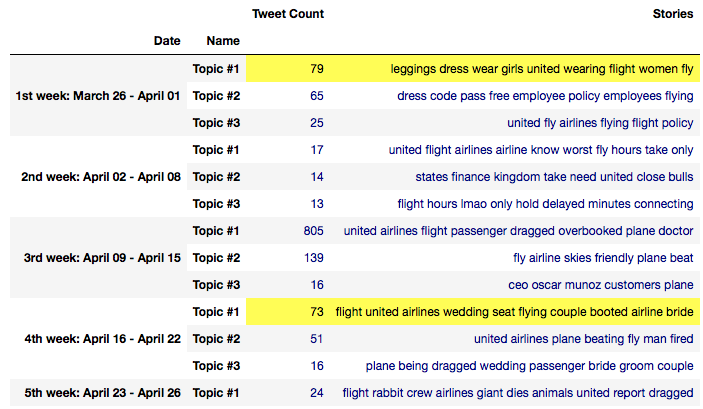

```python
Image(filename='TDI/Table.png',width=900, height=700)
```

An interesting fact in stories of 1st week (Topic #2) is about “dress code employee policy” which seems to have tweets about the event that two girls were prohibited to board because they were wearing leggings. When you investigate more, you will notice that the girls had “United employee” tickets and for that ticket you need to have a formal dress code.

Also, I can see that the UA incident (dragging a man out of UA airplane) has been dominant for at least two weeks. On the other hand, we don’t see this pattern for AA incident. I predict that until UA and the passenger reach a settlement, the discussions on twitter will be continued. I can further investigate this in the next stage of my capstone project.

### Plot #4: Zoomed Events for American Airlines

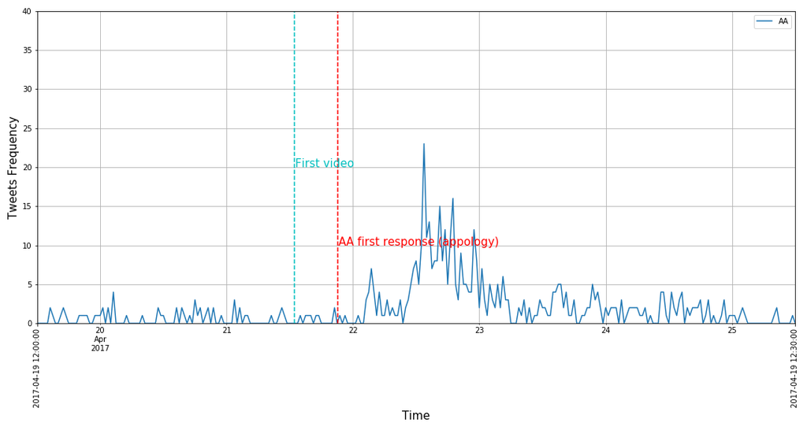

```python
Image(filename='TDI/timeseries_aa_zoom_3.png')
```

### Table #2: American Airline Stories Discovered From March 26th - April 26th

For American Airlines stories, mostly you will see normal topics, like flight cancelation and delays. Although the mentioned incident is being discovered in the stories, we don't see a very large number of tweet counts assigned to that story.

```python
pd_csv_aa = pd.read_csv('/Users/alinamazi/Documents/DI/Stories_aa.csv')
pd_csv_indexed_aa = pd_csv_aa.set_index(['Date', 'Name'])

def highlight_Stories(s):
    arr1 = s.index.get_level_values(1)=='Topic #1'
    arr2 = s.index.get_level_values(0)=='4th week: April 16 - April 22'
    is_highlight = arr1 & arr2

    return ['background-color: yellow' if v else 'color: darkblue' for v in is_highlight]

s = pd_csv_indexed_aa.style.apply(highlight_Stories)
s
```

| Date | Name | Tweet Count | Stories |
| --- | --- | --- | --- |
| 2nd week: April 02 - April 08 | Topic #1 | 18 | light hours cancelled delay still airport plane crew |
|  | Topic #2 | 11 | airport help departure bags miss explain trying |
| 4th week: April 16 - April 22 | Topic #1 | 30 | american flight attendant hit passenger employee airlines stroller mother woman |
|  | Topic #2 | 12 | american airlines need respect |

## The Most Common Phrases

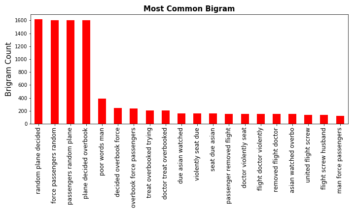

```python
Image(filename='TDI/bigrams_ua.png')
```

```python
#Image(filename='TDI/trigrams_ua.png')
```

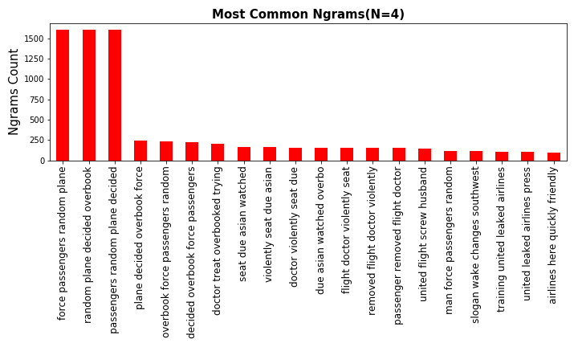

```python
Image(filename='TDI/ngrams_ua.png')
```

### Plot #5: American Airlines Most Common Bigrams, Trigrams, (N=4)grams

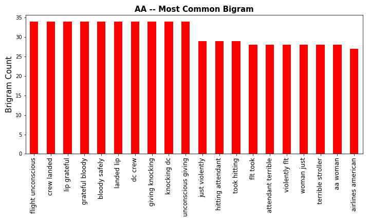

```python
Image(filename='TDI/bigrams_aa.png')
```

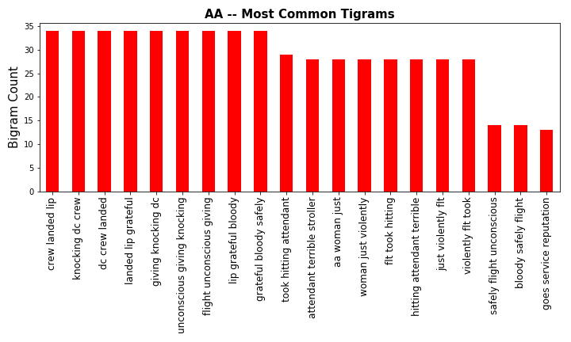

```python
Image(filename='TDI/trigrams_aa.png')
```

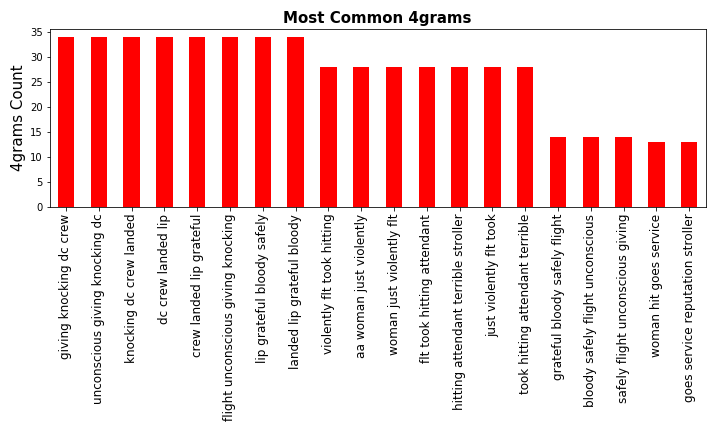

```python
Image(filename='TDI/ngrams_aa.png')
```